This follows on from Homework 4, where I asked you to fit the fossil data using mgcv with K = 4, 8 and 23.

```r
setwd("~/tamu/MS-STAT-2022/689-flexible-regression")
fossil = read.csv("fossil.csv")
library(mgcv)
#using K+2 to be consistent with our notation
gam4 = mgcv::gam(Strontium.Ratio~s(Age, k=6,bs="cr"), data=fossil)
gam8 = mgcv::gam(Strontium.Ratio~s(Age, k=10,bs="cr"), data=fossil)
gam23 = mgcv::gam(Strontium.Ratio~s(Age, k=25,bs="cr"), data=fossil)
```

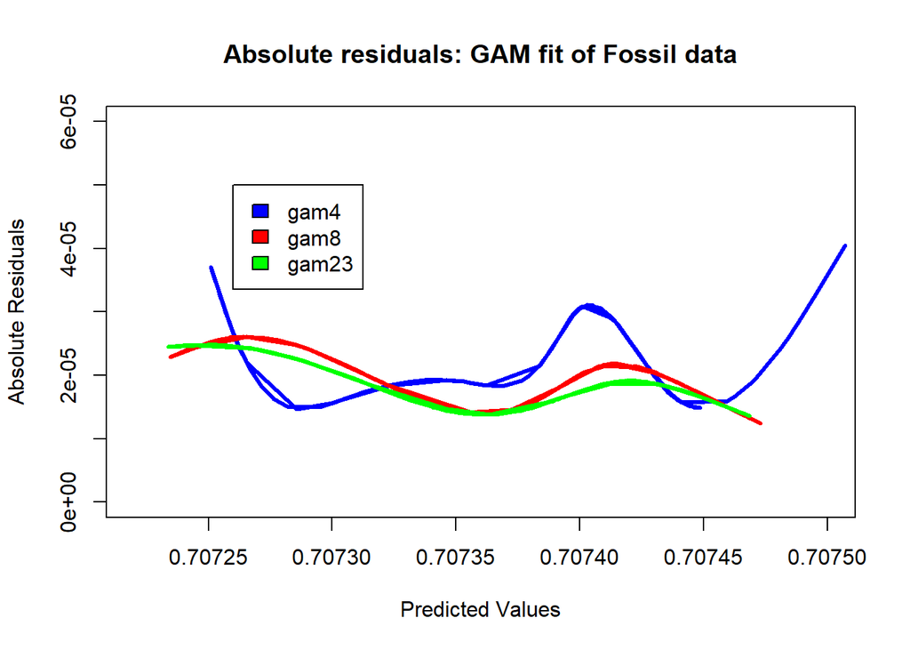

```r
plot(1, type="n"
     , xlim=c(0.70722, 0.70750)
     , ylim=c(0, 0.00006)
     , xlab="Predicted Values"
     , ylab="Absolute Residuals"
     , main="Absolute residuals: GAM fit of Fossil data"
     )
#gam4
ord <- order(fossil$Age)
x    = fitted(gam4)[ord]
y    = abs(gam4$residuals)[ord]
gam4_abs = gam(y~s(x,bs="cr"), data=fossil)
lines(x,fitted(gam4_abs),lwd=3,col="blue")

#gam8
ord <- order(fossil$Age)
x    = fitted(gam8)[ord]
y    = abs(gam8$residuals)[ord]
gam8_abs = gam(y~s(x,bs="cr"), data=fossil)
lines(x,fitted(gam8_abs),lwd=3,col="red")

#gam23
ord <- order(fossil$Age)
x    = fitted(gam23)[ord]
y    = abs(gam23$residuals)[ord]
gam23_abs = gam(y~s(x,bs="cr"), data=fossil)
lines(x,fitted(gam23_abs),lwd=3,col="green")

legend(0.70726, 0.00005, c("gam4", "gam8", "gam23"),
       fill = c("blue","red", "green")
       )
```

### 2. Give the ratio of the maximum fitted absolute residual to the minimum fitted absolute residual.

```r
var_ratio_k4 = (max(abs(fitted(gam4_abs))) / min(abs(fitted(gam4_abs))))^2
var_ratio_k8 = (max(abs(fitted(gam8_abs))) / min(abs(fitted(gam8_abs))))^2
var_ratio_k23 = (max(abs(fitted(gam23_abs))) / min(abs(fitted(gam23_abs))))^2
cat('k = 4 fit, maximum to minimum variance ratio = ',var_ratio_k4,"\n")
```

```
## k = 4 fit, maximum to minimum variance ratio =  7.632015
```

```r
cat('k = 8   fit, maximum to minimum variance ratio = ',var_ratio_k8,"\n")
```

```
## k = 8   fit, maximum to minimum variance ratio =  4.426046
```

```r
cat('k = 23  fit, maximum to minimum variance ratio = ',var_ratio_k23,"\n")
```

```
## k = 23  fit, maximum to minimum variance ratio =  3.340784
```

### 3. Do any of these fail my rule of thumb, i.e. that the ratio > 3, or the square of that ratio > 9? Remember, if this happens, the confidence region for the fit to Y from X is not reliable. Make sure you tell us what the ratio is for each choice of K.

None of the ratios are > 9.

k = 4 fit, ratio = 7.632015.

k = 8 fit, ratio = 4.426046.

k = 23 fit, ratio = 3.340784.

### 4. If any choice of K fails my rule of thumb, describe in words what that means. Remember, it is possible that the heteroscedasticity can occur in the middle of the X values, and not merely at the end.

For any values of K, if the ratios do not fall within the bounds of the rule of thumb, it indicates that our models fail to capture the non-constant variance present in the data. This means the confidence interval of fit to Y from X is not reliable.

In our case, all ratios are within the bounds of the rule of thumb.

### 5. By the way, give a verbal description of what K is

K refers to knots or basis functions. Our smoothed regression is tied together piecewise at these Ks. Generally, Ks are chosen to be approximately equally spaced at the quantiles of the Xs.